# moral y política

Camilo A. Ordóñez-Pinilla

7/12/2021

```r
options(scipen=999)
```

# RELACIONES ENTRE MORAL Y POLÍTICA

Los datos fueron recolectados a través de convocatoria abierta por redes sociales personales e institucionales de la Universidad El Bosque en marzo-abril 2018.

## ANÁLISIS DESCRIPTIVOS

Data Frame Summary

datos

**Dimensions**: 183 x 14  
**Duplicates**: 1

| **No** | **Variable** | **Stats / Values** | **Freqs (% of Valid)** | **Graph** | **Valid** | **Missing** |
| --- | --- | --- | --- | --- | --- | --- |
| 1 | edad [numeric] | Mean (sd) : 33.1 (12.8) min < med < max: 10 < 30 < 99 IQR (CV) : 12 (0.4) | 49 distinct values |  | 181 (98.9%) | 2 (1.1%) |
| 2 | genero [factor] | 1. femenino 2. masculino 3. otro | 101 ( 56.7% ) 73 ( 41.0% ) 4 ( 2.2% ) |  | 178 (97.3%) | 5 (2.7%) |
| 3 | estrato [numeric] | Mean (sd) : 3.4 (1.1) min < med < max: 1 < 3 < 6 IQR (CV) : 1 (0.3) | 1 : 3 ( 1.7% ) 2 : 31 ( 17.1% ) 3 : 80 ( 44.2% ) 4 : 33 ( 18.2% ) 5 : 28 ( 15.5% ) 6 : 6 ( 3.3% ) |  | 181 (98.9%) | 2 (1.1%) |
| 4 | decadencia_moral [factor] | 1. no 2. sí | 45 ( 24.9% ) 136 ( 75.1% ) |  | 181 (98.9%) | 2 (1.1%) |
| 5 | decadencia_corrupcion [numeric] | Mean (sd) : 3.8 (0.5) min < med < max: 1 < 4 < 4 IQR (CV) : 0 (0.1) | 1 : 2 ( 1.5% ) 2 : 2 ( 1.5% ) 3 : 20 ( 14.7% ) 4 : 112 ( 82.4% ) |  | 136 (74.3%) | 47 (25.7%) |
| 6 | decadencia_economia [numeric] | Mean (sd) : 3.5 (0.7) min < med < max: 1 < 4 < 4 IQR (CV) : 1 (0.2) | 1 : 2 ( 1.5% ) 2 : 11 ( 8.1% ) 3 : 38 ( 27.9% ) 4 : 85 ( 62.5% ) |  | 136 (74.3%) | 47 (25.7%) |
| 7 | decadencia_violencia [numeric] | Mean (sd) : 3.7 (0.5) min < med < max: 1 < 4 < 4 IQR (CV) : 0 (0.1) | 1 : 1 ( 0.7% ) 2 : 4 ( 2.9% ) 3 : 24 ( 17.6% ) 4 : 107 ( 78.7% ) |  | 136 (74.3%) | 47 (25.7%) |
| 8 | voto [factor] | 1. blanco 2. no_votó 3. votó | 28 ( 15.5% ) 19 ( 10.5% ) 134 ( 74.0% ) |  | 181 (98.9%) | 2 (1.1%) |
| 9 | vote_bueno [numeric] | Mean (sd) : 3.6 (0.9) min < med < max: 1 < 4 < 5 IQR (CV) : 1 (0.3) | 1 : 3 ( 2.2% ) 2 : 12 ( 9.0% ) 3 : 39 ( 29.1% ) 4 : 61 ( 45.5% ) 5 : 19 ( 14.2% ) |  | 134 (73.2%) | 49 (26.8%) |
| 10 | vote_bueno_influyo [numeric] | Mean (sd) : 3.1 (1.4) min < med < max: 0 < 4 < 5 IQR (CV) : 2 (0.5) | 0 : 13 ( 9.7% ) 1 : 4 ( 3.0% ) 2 : 24 ( 17.9% ) 3 : 25 ( 18.7% ) 4 : 53 ( 39.6% ) 5 : 15 ( 11.2% ) |  | 134 (73.2%) | 49 (26.8%) |
| 11 | novote_malo [numeric] | Mean (sd) : 3.3 (1.3) min < med < max: 1 < 3 < 5 IQR (CV) : 2 (0.4) | 1 : 16 ( 11.9% ) 2 : 19 ( 14.2% ) 3 : 35 ( 26.1% ) 4 : 35 ( 26.1% ) 5 : 29 ( 21.6% ) |  | 134 (73.2%) | 49 (26.8%) |
| 12 | novote_malo_influyo [numeric] | Mean (sd) : 3 (1.6) min < med < max: 0 < 3 < 5 IQR (CV) : 2.8 (0.5) | 0 : 11 ( 8.2% ) 1 : 13 ( 9.7% ) 2 : 32 ( 23.9% ) 3 : 25 ( 18.7% ) 4 : 19 ( 14.2% ) 5 : 34 ( 25.4% ) |  | 134 (73.2%) | 49 (26.8%) |
| 13 | nobueno_blanco [numeric] | Mean (sd) : 3.4 (1.4) min < med < max: 1 < 3.5 < 5 IQR (CV) : 3 (0.4) | 1 : 3 ( 10.7% ) 2 : 7 ( 25.0% ) 3 : 4 ( 14.3% ) 4 : 5 ( 17.9% ) 5 : 9 ( 32.1% ) |  | 28 (15.3%) | 155 (84.7%) |
| 14 | nobueno_novotar [numeric] | Mean (sd) : 3.1 (1.6) min < med < max: 1 < 3 < 5 IQR (CV) : 3 (0.5) | 1 : 4 ( 21.1% ) 2 : 4 ( 21.1% ) 3 : 4 ( 21.1% ) 4 : 1 ( 5.3% ) 5 : 6 ( 31.6% ) |  | 19 (10.4%) | 164 (89.6%) |

Generated by summarytools 0.9.9 ([R](https://www.r-project.org/) version 4.0.4)  
2021-10-01

La variable edad parece presentar algunos problemas en su rango.

```r
summary (datos$edad)
```

```
##    Min. 1st Qu.  Median    Mean 3rd Qu.    Max.    NA's
##   10.00   25.00   30.00   33.13   37.00   99.00       2
```

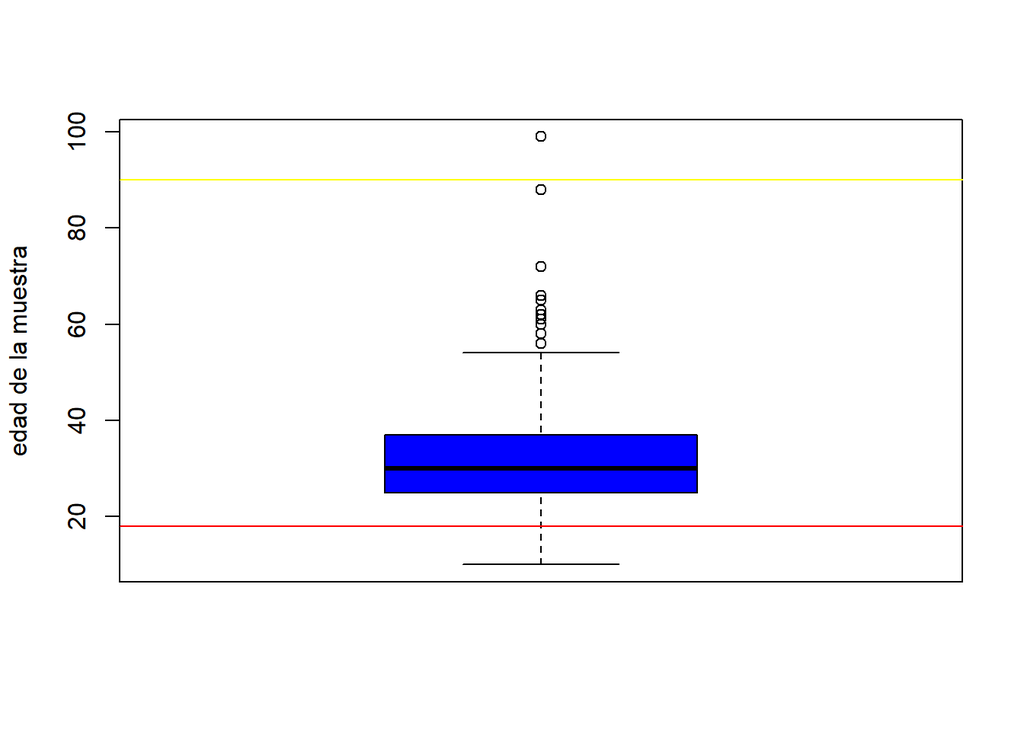

```r
boxplot (datos$edad, col="blue", ylab="edad de la muestra")
abline (h=18, col="red")
abline (h=90, col="yellow")
```

Esto muestra problemas con algunas observaciones según la edad: hay algunas bajo 18 años (línea roja) y una sobre 90 años (que es un valor de referencia para las pruebas previas que se realizaron). Por esta razón se procede a eliminar tales observaciones de la base de datos, pero sin eliminar las que tengan datos perdidos.

Y revisamos que la variable edad parezca estar bien

```
##    Min. 1st Qu.  Median    Mean 3rd Qu.    Max.    NA's
##    18.0    25.0    30.0    33.1    37.0    88.0       2
```

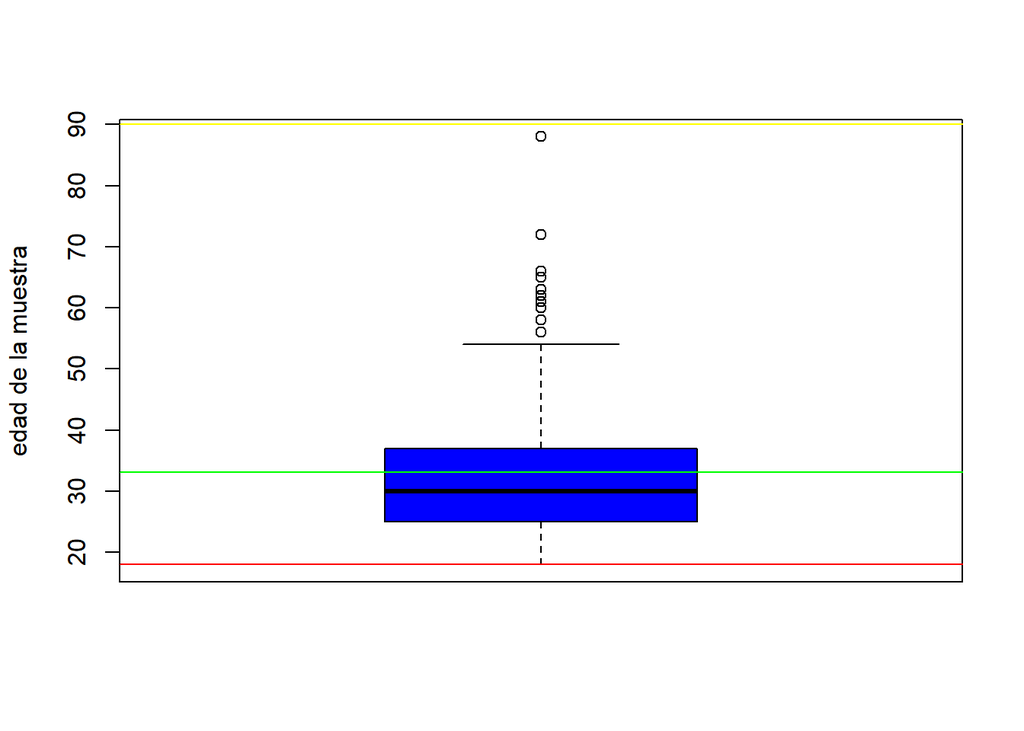

Lo que muestra que la edad de la muestra está concentrada en personas jóvenes entre 25 y 37 años, pero con varios casos que parecen extremos en edades altas.

```
##    Min. 1st Qu.  Median    Mean 3rd Qu.    Max.    NA's
##   1.000   3.000   3.000   3.412   4.000   6.000       2
```

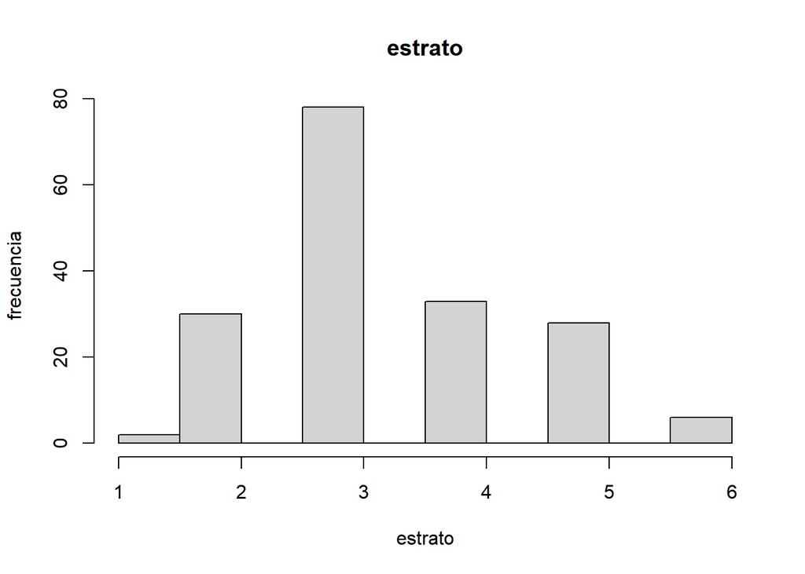

En cuanto a estrato, la muestra está concentrada en personas del estrato 3.

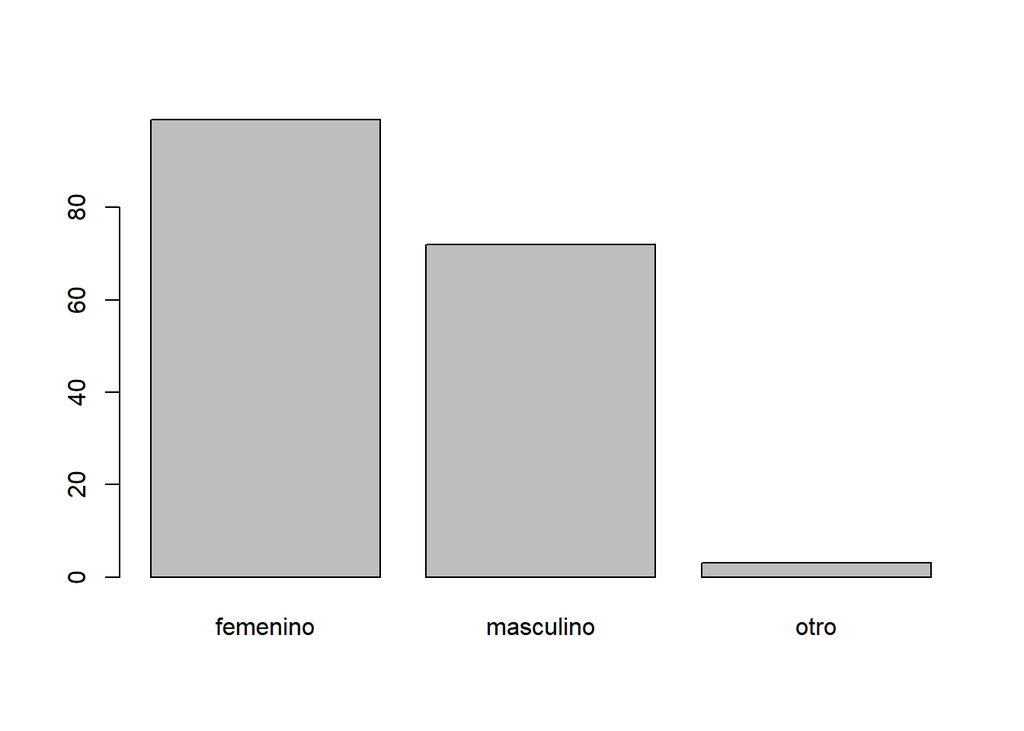

Y más o menos equilibrada en género, pero con una mayor representación del género femenino.

Así, la muestra no parece presentar problemas en su composición demográfica que potencialmente afecten los resultados.

```
##   no   sí NA's
##   45  132    2
```

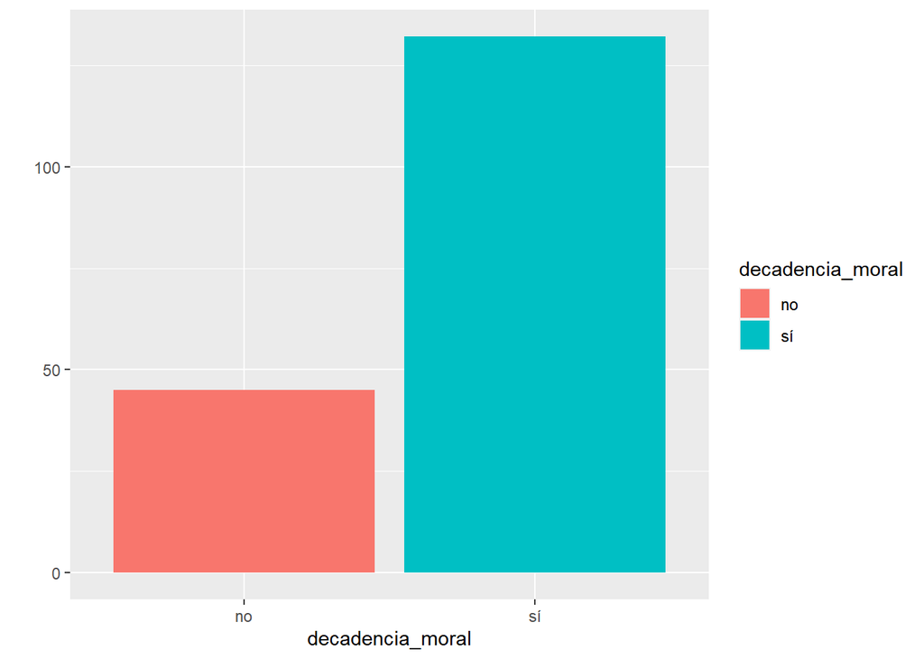

Una mayoría de personas parece considerar que en efecto se presenta un fenómeno de ‘decadencia moral’ en el país. Independientemente de qué signifique esto en concreto (dado que el término ‘moral’ puede tener significados más o menos diferentes que varíen de persona a persona), el punto está en que las personas consideran mayoritariamente que hay un ‘empeoramiento’ de la moralidad que es generalizado y por ende es importante ver las conexiones que las personas encuentran en tal empeoramiento y fenómenos que son claros problemas del país.

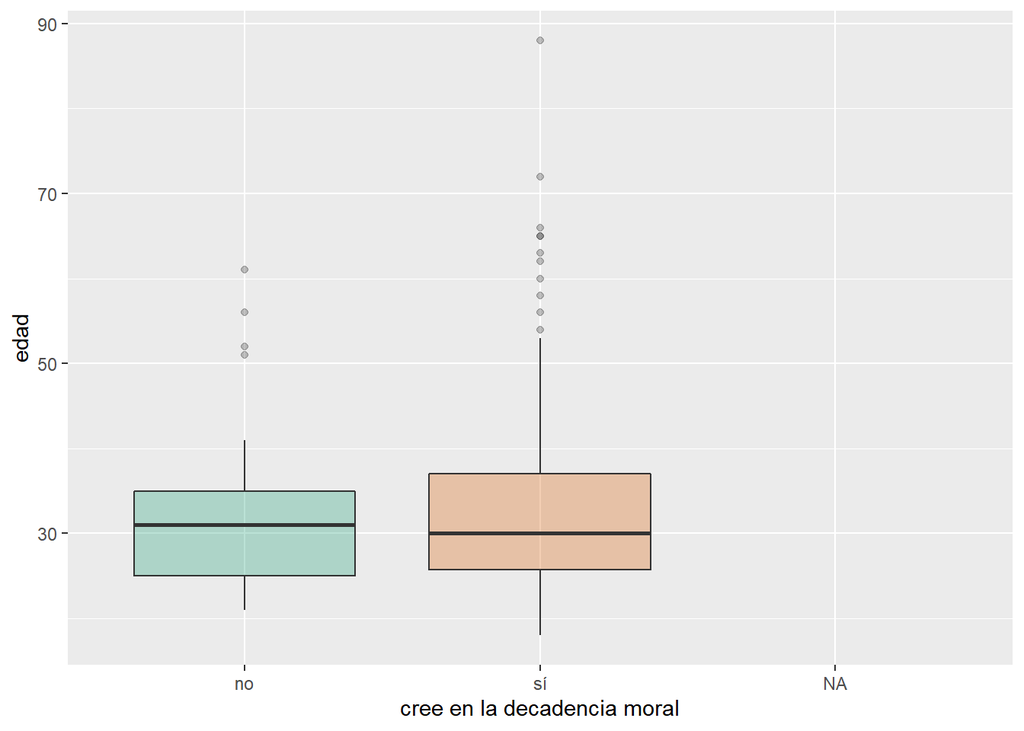

Exploratoriamente, el gráfico indica que la edad no parece ser un factor que haga una diferencia en la opinión de si hay o no una decadencia moral en el país.

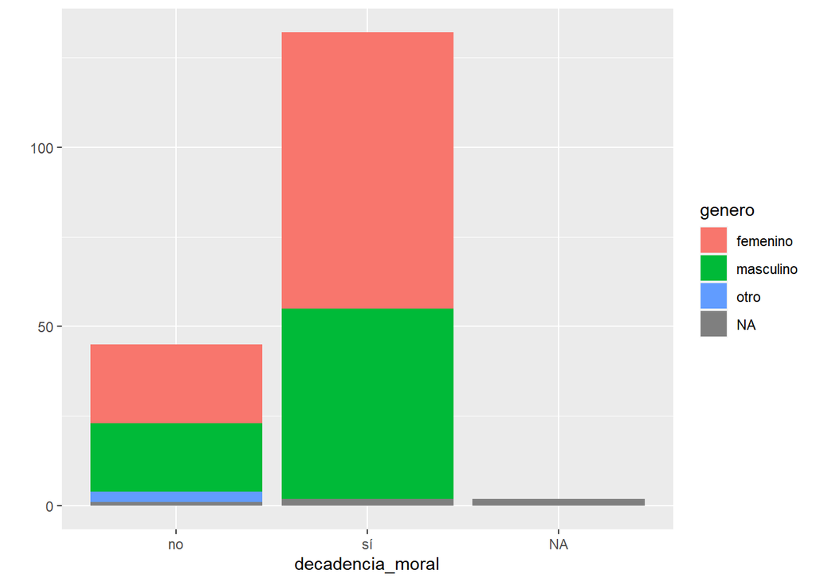

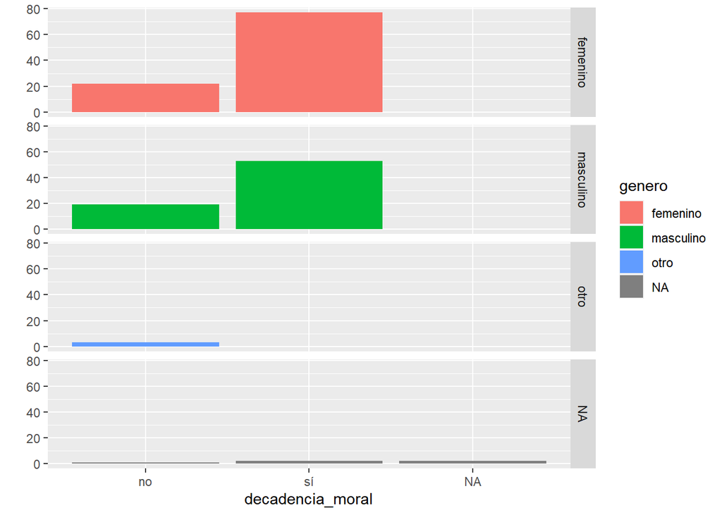

Estos gráficos tampoco parecen indicar un efecto del género sobre la creencia en la decadencia moral. Así, exploratoriamente, parecería que ni el género ni la edad se relacionan con diferentes creencias acerca de la decadencia moral del país.

Pero, al cruzar las categorías, encontramos algo que parece ser ligeramente diferente.

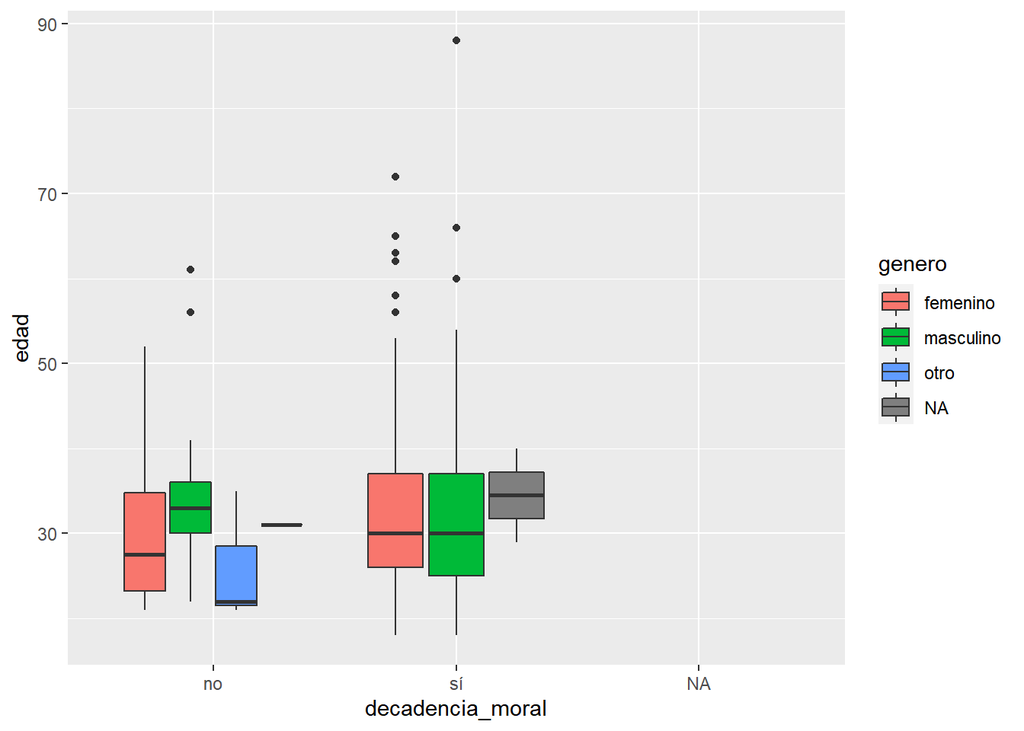

En cuanto al género, el gráfico exploratorio parece indicar que dentro del grupo de personas que creen que no hay una decandencia moral, las de género masculino tienden a tener una edad mayor que la de las personas de género femenino.

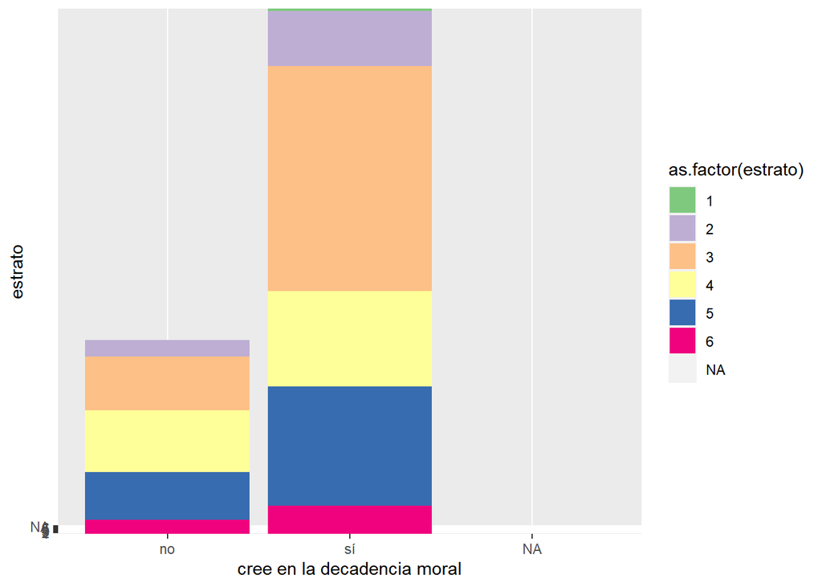

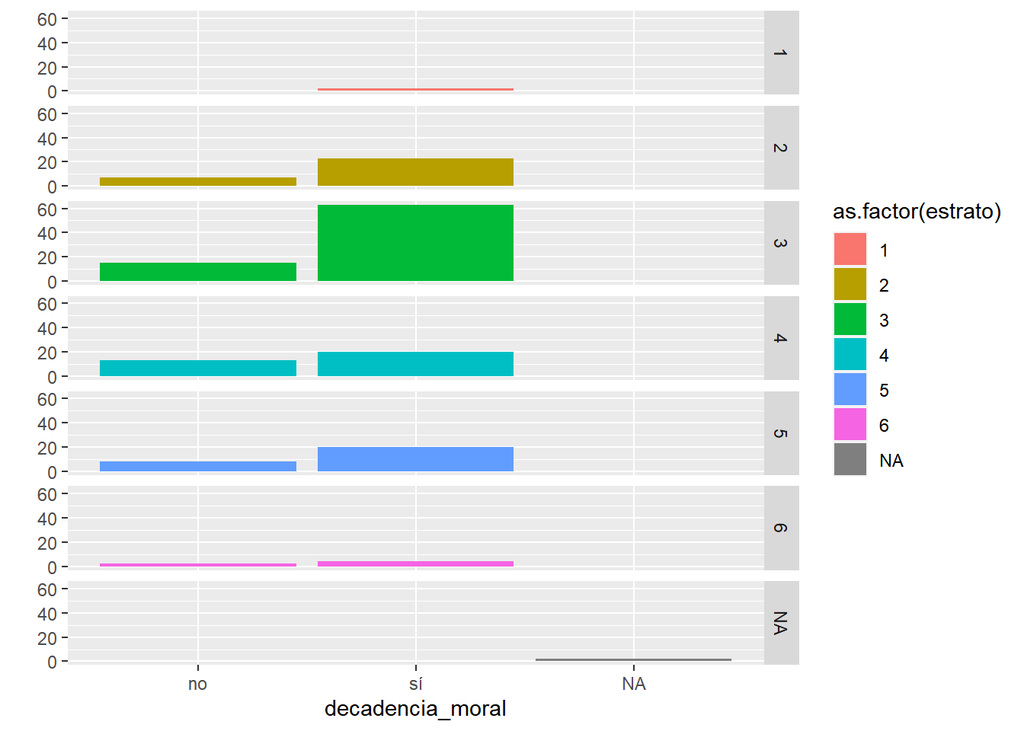

No hay personas de estrato 1 que crean que no hay decadencia moral.

```
##
##  1  2  3  4  5  6
##  2 30 78 33 28  6
```

Así, el estrato tampoco parece tener un efecto sobre la creencia de que el país está o no en una situación de decadencia moral, a excepción de lo que sucede en el estrato 3, donde sí parece haber una mayor proporción de personas que creen que sí hay una decadencia moral comparadas con las que creen que no la hay.

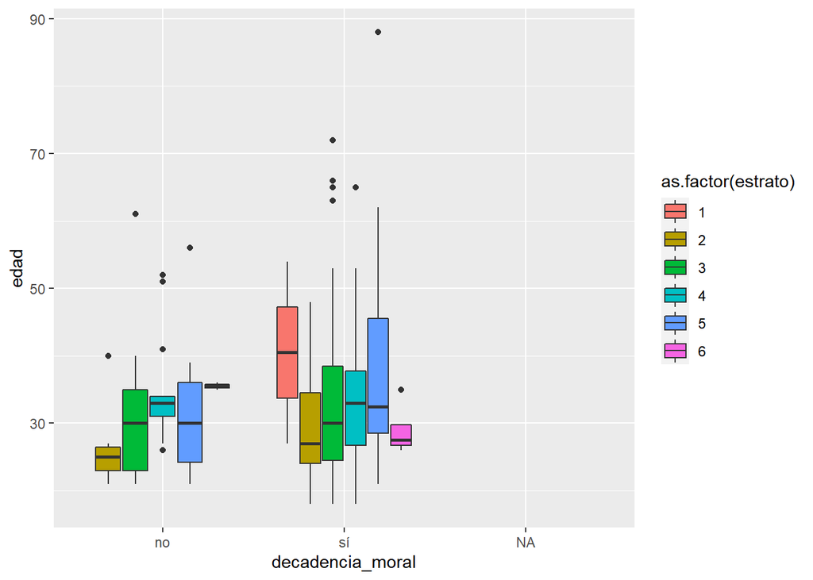

En este sentido, el género, el estrato o la edad -tomadas como variables demográficas importantes y representativas de situaciones sociales que podrían parecer relevantes y que algunas teorías, como la teoría de los fundamentos morales de Haidt, encuentran como explicativas de opiniones políticas y moralmente cargadas- no parecen de entrada tener un rol explicativo que resulte interesante.

Para ahondar en este punto, se ajustó un modelo de regresión logística, tomando la creencia de si se está o no en una situación de decadencia moral como la variable de clasificación (niveles: sí-no) y la edad, el género y el estrato como las variables predictoras.

```
## [1] "factor"
```

```
##
## Call:
## glm(formula = decadencia_moral ~ edad, family = binomial, data = datos)
##
## Deviance Residuals:
##     Min       1Q   Median       3Q      Max
## -1.8079  -1.5915   0.7528   0.7890   0.8263
##
## Coefficients:
##             Estimate Std. Error z value Pr(>|z|)
## (Intercept)  0.68232    0.54005   1.263    0.206
## edad         0.01205    0.01585   0.760    0.447
##
## (Dispersion parameter for binomial family taken to be 1)
##
##     Null deviance: 200.70  on 176  degrees of freedom
## Residual deviance: 200.09  on 175  degrees of freedom
##   (2 observations deleted due to missingness)
## AIC: 204.09
##
## Number of Fisher Scoring iterations: 4
```

como se esperaba, la edad no parece ser un predictor de la creencia en la decadencia moral (p=.44).

```
##
## Call:
## glm(formula = decadencia_moral ~ estrato, family = binomial,
##     data = datos)
##
## Deviance Residuals:
##     Min       1Q   Median       3Q      Max
## -1.8119  -1.3866   0.7290   0.7290   0.9817
##
## Coefficients:
##             Estimate Std. Error z value Pr(>|z|)
## (Intercept)   1.8995     0.5863   3.240   0.0012 **
## estrato      -0.2367     0.1580  -1.498   0.1342
## ---
## Signif. codes:  0 '***' 0.001 '**' 0.01 '*' 0.05 '.' 0.1 ' ' 1
##
## (Dispersion parameter for binomial family taken to be 1)
##
##     Null deviance: 200.70  on 176  degrees of freedom
## Residual deviance: 198.46  on 175  degrees of freedom
##   (2 observations deleted due to missingness)
## AIC: 202.46
##
## Number of Fisher Scoring iterations: 4
```

El estrato tampoco parece tener un efecto sobre la creencia en la decadencia moral (p=0.13)

```
##
## Call:
## glm(formula = decadencia_moral ~ genero, family = binomial, data = datos)
##
## Deviance Residuals:
##     Min       1Q   Median       3Q      Max
## -1.7344   0.1768   0.7090   0.7828   0.7828
##
## Coefficients:
##                 Estimate Std. Error z value    Pr(>|z|)
## (Intercept)       1.2528     0.2417   5.182 0.000000219 ***
## generomasculino  -0.2269     0.3605  -0.629       0.529
## generootro      -16.8188   840.2742  -0.020       0.984
## ---
## Signif. codes:  0 '***' 0.001 '**' 0.01 '*' 0.05 '.' 0.1 ' ' 1
##
## (Dispersion parameter for binomial family taken to be 1)
##
##     Null deviance: 196.78  on 173  degrees of freedom
## Residual deviance: 187.98  on 171  degrees of freedom
##   (5 observations deleted due to missingness)
## AIC: 193.98
##
## Number of Fisher Scoring iterations: 14
```

De manera similar, pertenecer al género femenino no se asocia a una mayor probabilidad de tener una u otra creencia sobre la decadencia moral, en comparación con pertenecer al género masculino (p=0.52) u otro género (p=0.98).

```
##
## Call:
## glm(formula = decadencia_moral ~ estrato + genero + edad, family = binomial,
##     data = datos)
##
## Deviance Residuals:
##     Min       1Q   Median       3Q      Max
## -1.8595   0.1311   0.6804   0.7505   1.0394
##
## Coefficients:
##                  Estimate Std. Error z value Pr(>|z|)
## (Intercept)       1.71965    0.76356   2.252   0.0243 *
## estrato          -0.25000    0.16728  -1.494   0.1350
## generomasculino  -0.18814    0.36424  -0.517   0.6055
## generootro      -16.69841  827.48368  -0.020   0.9839
## edad              0.01162    0.01625   0.715   0.4745
## ---
## Signif. codes:  0 '***' 0.001 '**' 0.01 '*' 0.05 '.' 0.1 ' ' 1
##
## (Dispersion parameter for binomial family taken to be 1)
##
##     Null deviance: 196.78  on 173  degrees of freedom
## Residual deviance: 185.49  on 169  degrees of freedom
##   (5 observations deleted due to missingness)
## AIC: 195.49
##
## Number of Fisher Scoring iterations: 14
```

```
##                               OR     2.5 %
## (Intercept)     5.58259864161458 1.2539950
## estrato         0.77880307636517 0.5592783
## generomasculino 0.82849711704875 0.4057926
## generootro      0.00000005597201        NA
## edad            1.01169186204070 0.9814554
##                                                          97.5 %
## (Intercept)                                           25.485809
## estrato                                                1.081627
## generomasculino                                        1.703528
## generootro      3815646838763286561864084222882260640604.000000
## edad                                                   1.046838
```

Y el modelo complejo también confirma que las variables demográficas consideradas no parecen tener un potencial explicativo relevante para entender que las personas crean que hay o no una decadencia moral en el país.

Hubiera sido interesante ver si variables como la autoidentificación en el espectro político (derecha-izquierda-centro) o la creencia religiosa pueden tener un efecto sobre la evaluación que se hace de la decadencia moral del país. Tales variables no se midieron en el instrumento.

```
##    Min. 1st Qu.  Median    Mean 3rd Qu.    Max.    NA's
##   1.000   4.000   4.000   3.803   4.000   4.000      47
```

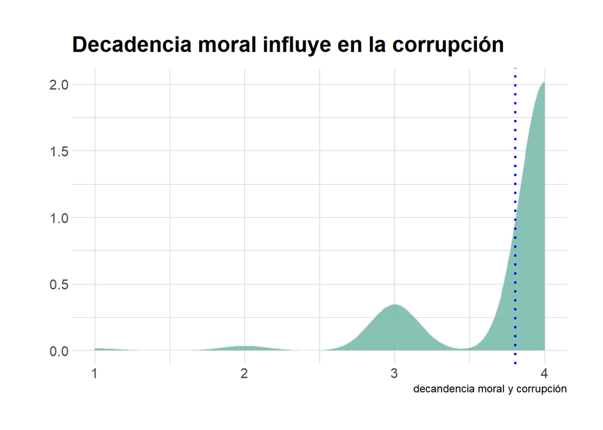

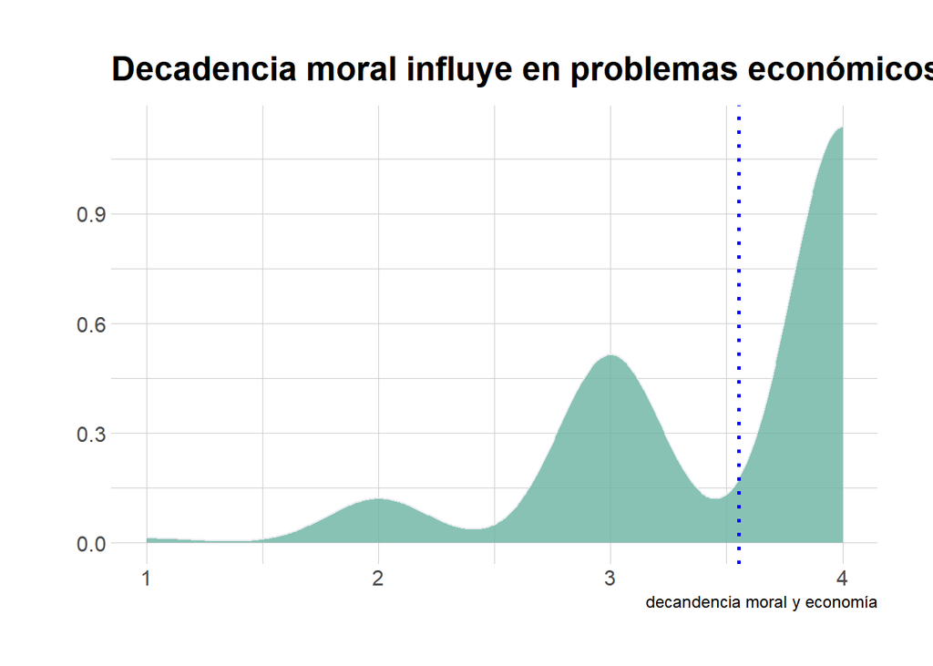

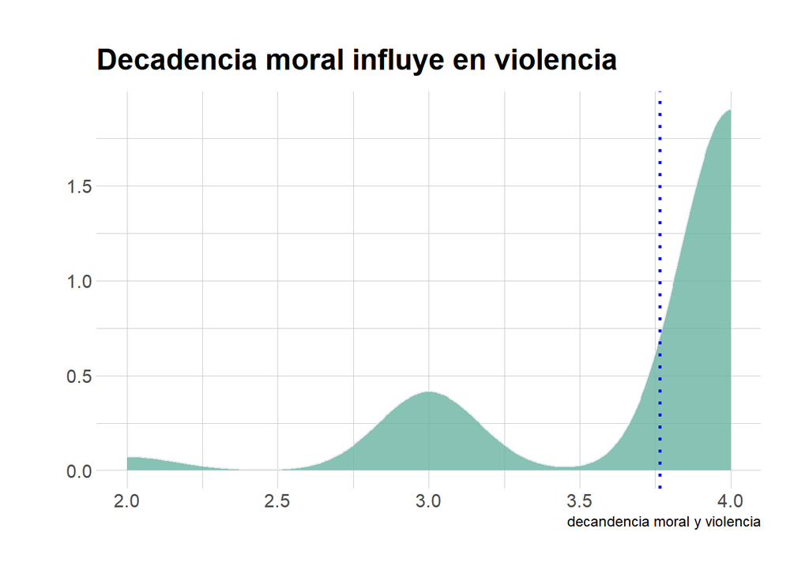

```
## $`1`
```

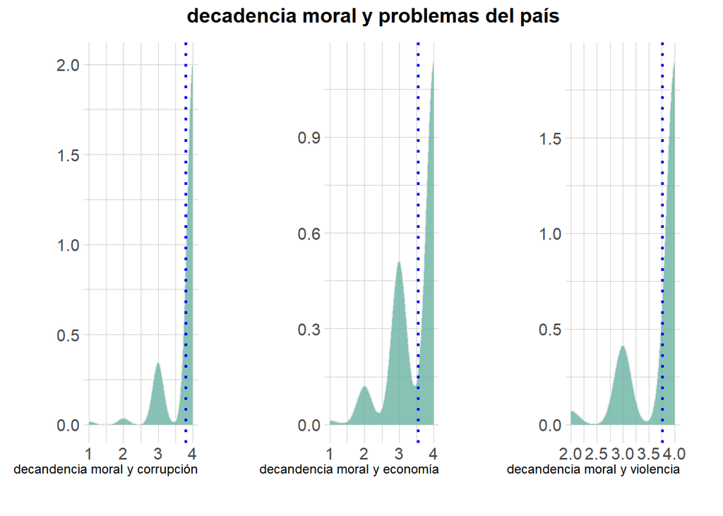

```
##
## $`2`
```

[figure not shown]

```
##
## attr(,"class")
## [1] "list"      "ggarrange"
```

```
##  mean CI-95%
##  3.80 [3.72;3.89]
```

```
## [1] 0.4855059
```

```
##  mean CI-95%
##  3.55 [3.44;3.67]
```

```
## [1] 0.6574807
```

```
##  mean CI-95%
##  3.77 [3.68;3.85]
```

```
## [1] 0.4920722
```

Ahora buscamos efectos de las variables demográficas sobre estas creencias en la relación entre decadencia moral y problemas del país

```
##
## Call:
## lm(formula = decadencia_corrupcion ~ estrato + genero + edad,
##     data = datos)
##
## Residuals:
##     Min      1Q  Median      3Q     Max
## -2.7592  0.1269  0.1469  0.2453  0.2662
##
## Coefficients:
##                   Estimate Std. Error t value            Pr(>|t|)
## (Intercept)      3.7587820  0.1737786  21.630 <0.0000000000000002 ***
## estrato         -0.0060798  0.0405534  -0.150               0.881
## generomasculino  0.1158893  0.0879032   1.318               0.190
## edad             0.0004249  0.0035288   0.120               0.904
## ---
## Signif. codes:  0 '***' 0.001 '**' 0.01 '*' 0.05 '.' 0.1 ' ' 1
##
## Residual standard error: 0.491 on 126 degrees of freedom
##   (49 observations deleted due to missingness)
## Multiple R-squared:  0.01365,    Adjusted R-squared:  -0.00983
## F-statistic: 0.5814 on 3 and 126 DF,  p-value: 0.6283
```

Este modelo parece indicar que no hay relación entre variables demográficas y la creencia en que la decadencia moral se relaciona con la corrupción.

```
##
## Call:
## lm(formula = decadencia_economia ~ estrato + genero + edad, data = datos)
##
## Residuals:
##     Min      1Q  Median      3Q     Max
## -2.5991 -0.5112  0.3743  0.4329  0.6732
##
## Coefficients:
##                   Estimate Std. Error t value            Pr(>|t|)
## (Intercept)      3.7954476  0.2341800  16.207 <0.0000000000000002 ***
## estrato         -0.0796699  0.0546488  -1.458               0.147
## generomasculino  0.0298279  0.1184564   0.252               0.802
## edad             0.0003466  0.0047554   0.073               0.942
## ---
## Signif. codes:  0 '***' 0.001 '**' 0.01 '*' 0.05 '.' 0.1 ' ' 1
##
## Residual standard error: 0.6617 on 126 degrees of freedom
##   (49 observations deleted due to missingness)
## Multiple R-squared:  0.01702,    Adjusted R-squared:  -0.006386
## F-statistic: 0.7272 on 3 and 126 DF,  p-value: 0.5376
```

```
##
## Call:
## lm(formula = decadencia_violencia ~ estrato + genero + edad,
##     data = datos)
##
## Residuals:
##      Min       1Q   Median       3Q      Max
## -1.83707  0.08219  0.18079  0.24799  0.48364
##
## Coefficients:
##                  Estimate Std. Error t value            Pr(>|t|)
## (Intercept)      4.061795   0.164746  24.655 <0.0000000000000002 ***
## estrato         -0.041373   0.038445  -1.076               0.284
## generomasculino  0.087566   0.083334   1.051               0.295
## edad            -0.005461   0.003345  -1.632               0.105
## ---
## Signif. codes:  0 '***' 0.001 '**' 0.01 '*' 0.05 '.' 0.1 ' ' 1
##
## Residual standard error: 0.4655 on 126 degrees of freedom
##   (49 observations deleted due to missingness)
## Multiple R-squared:  0.04302,    Adjusted R-squared:  0.02024
## F-statistic: 1.888 on 3 and 126 DF,  p-value: 0.1349
```

Las variables demográficas no parecen mostrar un efecto diferenciado en estas creencias. Estas creencias son transversales a las variables demográficas.

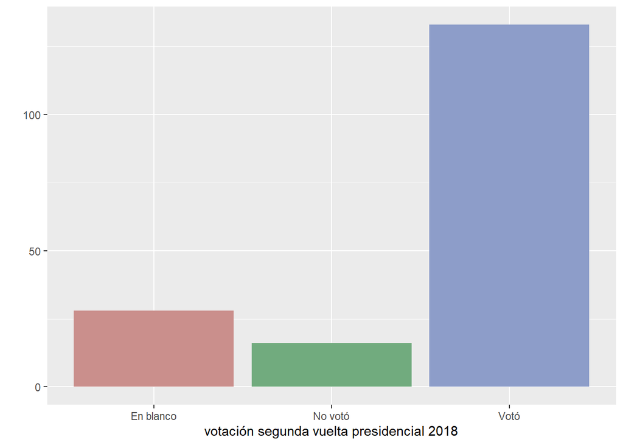

Queremos ver si los demográficos tienen algún efecto sobre estas decisiones de comportamiento electoral usando una regresión multinomial

```
## Call:
## multinom(formula = voto ~ edad + genero + estrato, data = datos)
##
## Coefficients:
##         (Intercept)        edad generomasculino generootro    estrato
## no_votó  -0.9060779 -0.02064096        1.767703   9.507760 0.01662771
## votó      2.0804803 -0.02435678        0.371584   7.221335 0.04085527
##
## Std. Errors:
##         (Intercept)       edad generomasculino generootro   estrato
## no_votó   1.3420867 0.02686545       0.7133124  0.6711880 0.2973671
## votó      0.8434431 0.01639833       0.4467734  0.6712872 0.2022346
##
## Residual Deviance: 242.9027
## AIC: 262.9027
```

Podemos calcular los coeficientes

```
##         (Intercept)        edad generomasculino generootro    estrato
## no_votó  -0.9060779 -0.02064096        1.767703   9.507760 0.01662771
## votó      2.0804803 -0.02435678        0.371584   7.221335 0.04085527
```

Los odds

```
##         (Intercept)      edad generomasculino generootro  estrato
## no_votó    0.404106 0.9795706        5.857384  13463.796 1.016767
## votó       8.008314 0.9759375        1.450030   1368.314 1.041701
```

Y los p-values

```
##         (Intercept)      edad generomasculino
## no_votó   0.4995956 0.4423038      0.01320615
## votó      0.0136383 0.1374589      0.40557498
##                                                    generootro   estrato
## no_votó 0.000000000000000000000000000000000000000000001496492 0.9554084
## votó    0.000000000000000000000000005466517557275040225649859 0.8399017
```

ÚNICO RESULTADO IMPORTANTE: más probable que los que no voten sean de género masculino comparado con los que votan en blanco (odds=5.85) [HOMBRES PREFIEREN NO VOTAR A VOTAR EN BLANCO]

Vamos a ver si hay una relación entre creer en la decadencia moral y tomar una cierta decisión electoral

```
##
##  Pearson's Chi-squared test
##
## data:  datos$decadencia_moral and datos$voto
## X-squared = 1.0366, df = 2, p-value = 0.5955
```

```
##
##  Pearson's Chi-squared test with simulated p-value (based on 2000
##  replicates)
##
## data:  datos$decadencia_moral and datos$voto
## X-squared = 1.0366, df = NA, p-value = 0.6172
```

Al parecer no podemos rechazar la hipótesis nula y por ende afirmar una cierta relación entre ambas, debemos seguir suponiendo que son independientes.

Buscamos analizar en más detalle con una regresión multinomial

```
## Call:
## multinom(formula = voto ~ decadencia_moral, data = datos)
##
## Coefficients:
##         (Intercept) decadencia_moralsí
## no_votó  -0.2231419         -0.4274379
## votó      1.9740718         -0.5348492
##
## Std. Errors:
##         (Intercept) decadencia_moralsí
## no_votó   0.6708177          0.7594787
## votó      0.4772592          0.5306262
##
## Residual Deviance: 255.0968
## AIC: 263.0968
```

Los odds

```
##         (Intercept) decadencia_moralsí
## no_votó   0.8000013          0.6521779
## votó      7.1999338          0.5857576
```

Y los p-values

```
##          (Intercept) decadencia_moralsí
## no_votó 0.7394047851          0.5735682
## votó    0.0000353001          0.3134743
```

Esto parece indicar que las variables son independientes: la creencia en la decadencia moral es transversal a las diferentes decisiones electorales.

```
## Call:
## multinom(formula = voto ~ decadencia_corrupcion, data = datos)
##
## Coefficients:
##         (Intercept) decadencia_corrupcion
## no_votó   -3.972663             0.8602948
## votó       1.270607             0.0445083
##
## Std. Errors:
##         (Intercept) decadencia_corrupcion
## no_votó    4.148209             1.0607031
## votó       1.748910             0.4579985
##
## Residual Deviance: 196.7341
## AIC: 204.7341
```

```
##         (Intercept) decadencia_corrupcion
## no_votó  0.01882324              2.363858
## votó     3.56301594              1.045514
```

```
##         (Intercept) decadencia_corrupcion
## no_votó   0.3382234             0.4173307
## votó      0.4675238             0.9225835
```

También parece haber independencia entre creer en la relación decadencia moral - corrupción y las decisiones electorales.

```
## Call:
## multinom(formula = voto ~ decadencia_economia, data = datos)
##
## Coefficients:
##         (Intercept) decadencia_economia
## no_votó   -30.75493          7.66199049
## votó        1.15639          0.08088408
##
## Std. Errors:
##         (Intercept) decadencia_economia
## no_votó   70.939916          17.7366367
## votó       1.205321           0.3393098
##
## Residual Deviance: 186.1208
## AIC: 194.1208
```

```
##                    (Intercept) decadencia_economia
## no_votó 0.00000000000004398479         2125.984971
## votó    3.17843941177929245612            1.084245
```

```
##         (Intercept) decadencia_economia
## no_votó   0.6646262           0.6657511
## votó      0.3373551           0.8115877
```

También hay independencia entre la creencia en la relación decadencia-moral y problemas económicos y las decisiones electorales

```
## Call:
## multinom(formula = voto ~ decadencia_violencia, data = datos)
##
## Coefficients:
##         (Intercept) decadencia_violencia
## no_votó -29.8455276            7.3969287
## votó     -0.6178285            0.5563424
##
## Std. Errors:
##         (Intercept) decadencia_violencia
## no_votó   75.293453           18.8249159
## votó       1.509323            0.4078791
##
## Residual Deviance: 190.136
## AIC: 198.136
```

```
##                   (Intercept) decadencia_violencia
## no_votó 0.0000000000001092074          1630.967613
## votó    0.5391138568391138364             1.744281
```

```
##         (Intercept) decadencia_violencia
## no_votó   0.6918178            0.6943690
## votó      0.6822892            0.1725712
```

Por último, también parece haber independencia entre creer en la relación decadencia moral - violencia y las decisiones electorales.

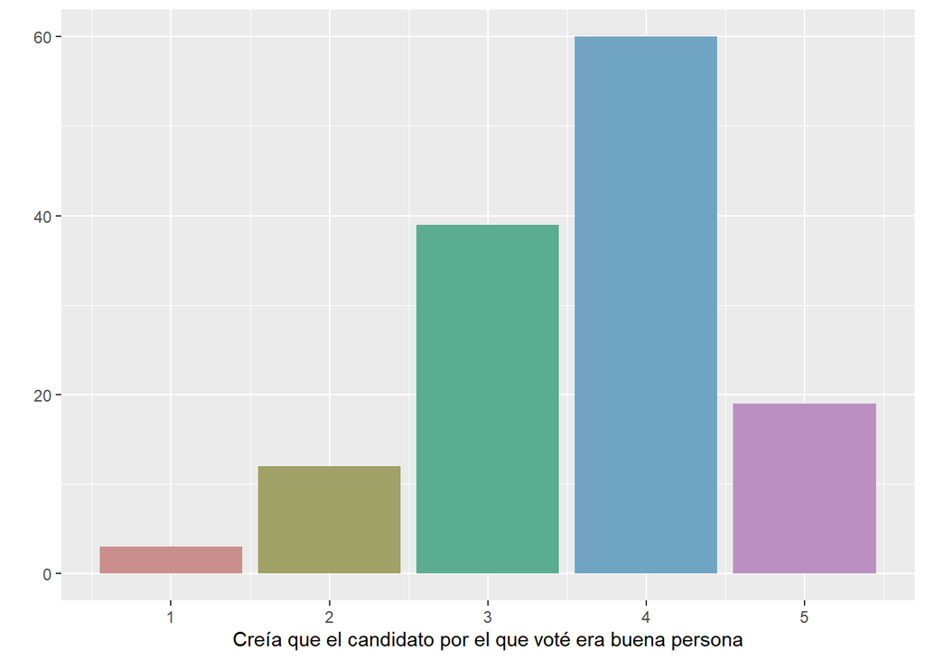

De las personas que votaron, la mayoría parecen considerar que su candidato era buena persona.

```
## [1] "character"
```

```
##
## no sí
## 54 79
```

Es necesario cambiar la clase de la nueva variable para que sea una variable categórica

```
## [1] "factor"
```

```
##
## no sí
## 54 79
```

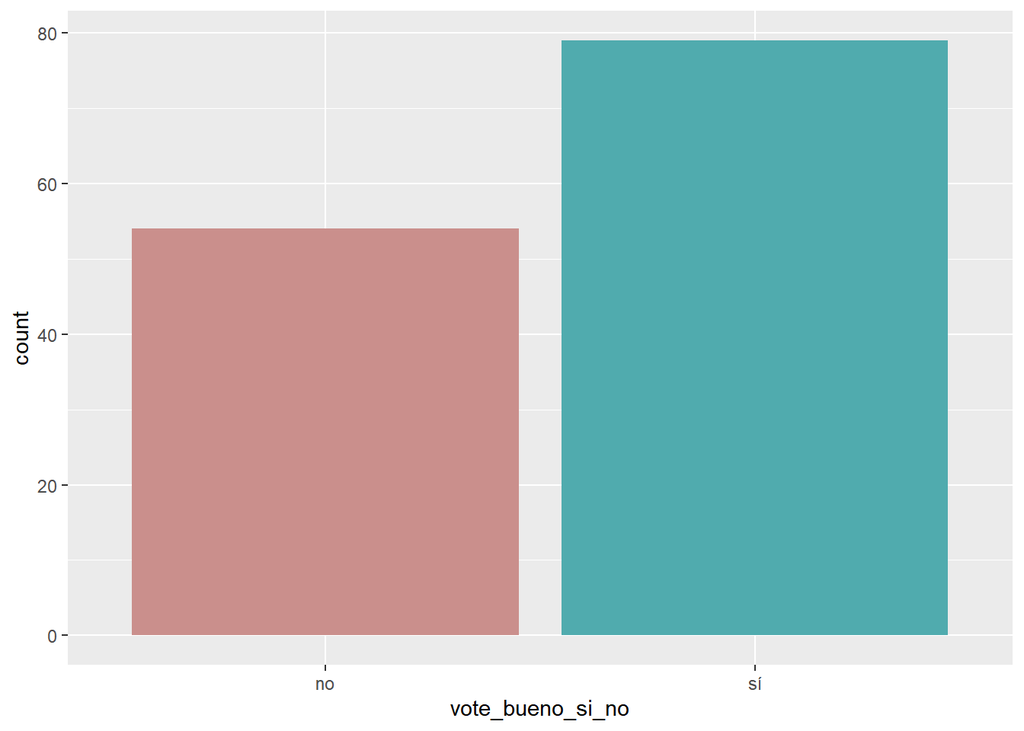

Ahora podemos evaluar si hay efecto de los demográficos sobre el creer que el candidato por el que se votó era buena persona

```
##
## Call:
## glm(formula = vote_bueno_si_no ~ estrato + genero + edad, family = binomial,
##     data = datos)
##
## Deviance Residuals:
##     Min       1Q   Median       3Q      Max
## -1.7519  -1.1946   0.7899   1.0456   1.4592
##
## Coefficients:
##                   Estimate Std. Error z value Pr(>|z|)
## (Intercept)        0.10673    0.80632   0.132   0.8947
## estrato           -0.36241    0.18204  -1.991   0.0465 *
## generomasculino    0.20815    0.38115   0.546   0.5850
## generootro        15.45306 1023.78022   0.015   0.9880
## edad               0.04254    0.01924   2.211   0.0271 *
## ---
## Signif. codes:  0 '***' 0.001 '**' 0.01 '*' 0.05 '.' 0.1 ' ' 1
##
## (Dispersion parameter for binomial family taken to be 1)
##
##     Null deviance: 176.48  on 129  degrees of freedom
## Residual deviance: 165.75  on 125  degrees of freedom
##   (49 observations deleted due to missingness)
## AIC: 175.75
##
## Number of Fisher Scoring iterations: 14
```

```
##                              OR
## (Intercept)           1.1126371
## estrato               0.6959938
## generomasculino       1.2313956
## generootro      5142549.0672362
## edad                  1.0434593
##                                                                                    2.5 %
## (Intercept)     0.2239107961679229485962849821589770726859569549560546875000000000000000
## estrato         0.4810086088431803630349747891159495338797569274902343750000000000000000
## generomasculino 0.5857111900392671932635835219116415828466415405273437500000000000000000
## generootro      0.0000000000000000000000000000000000000000000000000000000000000009844695
## edad            1.0069076431166845697617873156559653580188751220703125000000000000000000
##                    97.5 %
## (Intercept)     5.4006166
## estrato         0.9872838
## generomasculino 2.6250278
## generootro             NA
## edad            1.0865549
```

Como es usual tomando como referencia un alpha de 0.05, este modelo logit nos muestra que el estrato (p=0.04) y la edad (p=0.02) tienen un efecto sobre la creencia de que el candidato por el que se votó era una buena persona. Un aumento de una unidad de estrato disminuye en un factor de 0.69 las probabilidades (los odds ¿?) de creer que la persona por la que se votó es buena persona, mientra que un aumento en un año de edad aumenta tales probabilidades en un factor de 1.04. De todas maneras son diferencias relativamente pequeñas.

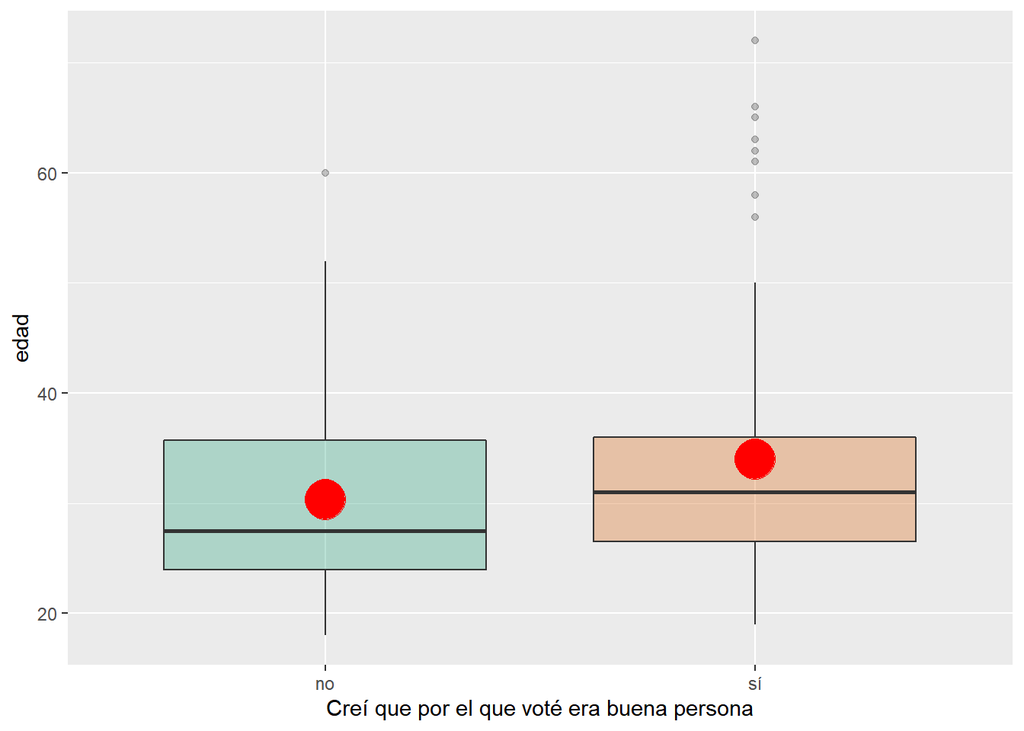

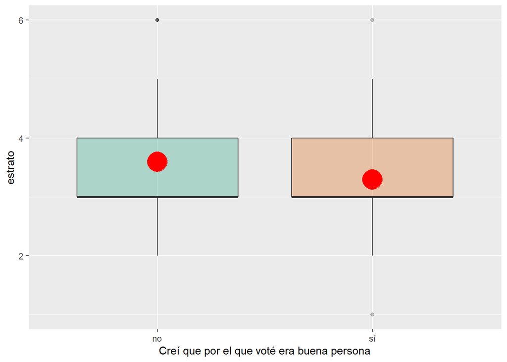

En las gráficas vemos las diferencias, que resultaron tener tamaños de efecto pequeños, pero estadísticamente significativos.

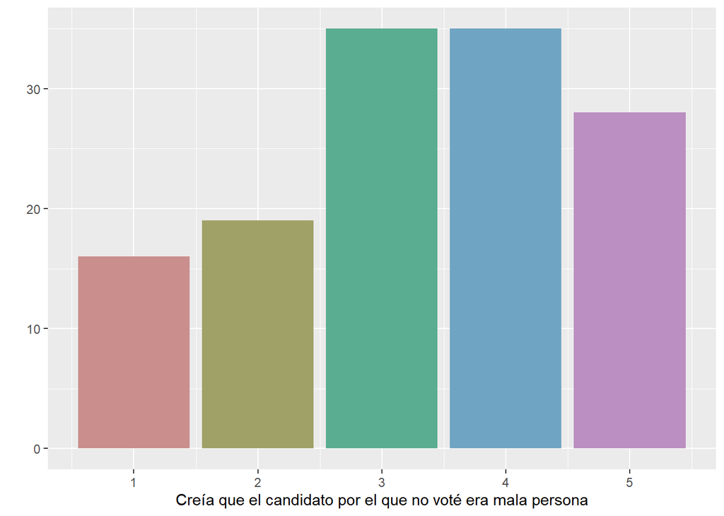

Creamos una nueva variable ‘no_vote_malo_si_no’

Y vemos su distribución al tomarla como una variable de factor

```
## [1] "factor"
```

```
##
## no sí
## 70 63
```

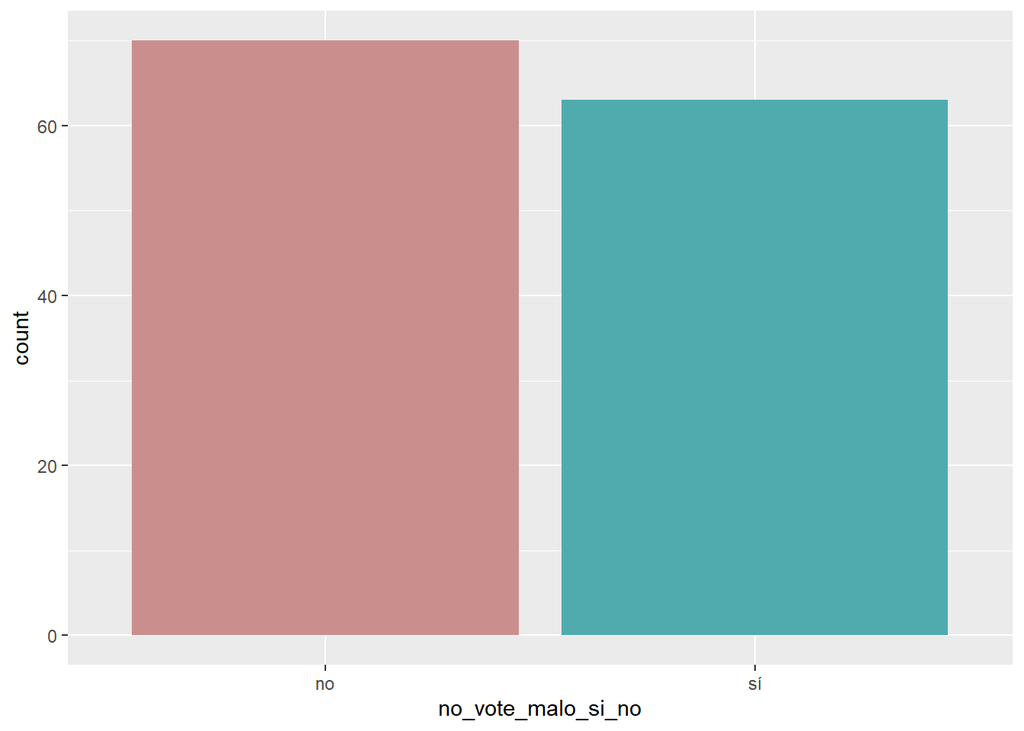

Efectos de demográficas

```
##
## Call:
## glm(formula = no_vote_malo_si_no ~ estrato + genero + edad, family = binomial,
##     data = datos)
##
## Deviance Residuals:
##     Min       1Q   Median       3Q      Max
## -1.5991  -1.0878  -0.8921   1.1997   1.5042
##
## Coefficients:
##                 Estimate Std. Error z value Pr(>|z|)
## (Intercept)     -1.53260    0.78631  -1.949   0.0513 .
## estrato          0.27561    0.17643   1.562   0.1183
## generomasculino -0.39178    0.37208  -1.053   0.2924
## generootro       0.43331    1.45362   0.298   0.7656
## edad             0.01908    0.01681   1.135   0.2562
## ---
## Signif. codes:  0 '***' 0.001 '**' 0.01 '*' 0.05 '.' 0.1 ' ' 1
##
## (Dispersion parameter for binomial family taken to be 1)
##
##     Null deviance: 179.73  on 129  degrees of freedom
## Residual deviance: 174.62  on 125  degrees of freedom
##   (49 observations deleted due to missingness)
## AIC: 184.62
##
## Number of Fisher Scoring iterations: 4
```

```
##                        OR      2.5 %     97.5 %
## (Intercept)     0.2159745 0.04421519  0.9822326
## estrato         1.3173329 0.93639229  1.8793161
## generomasculino 0.6758525 0.32268195  1.3945374
## generootro      1.5423546 0.05796490 41.1213267
## edad            1.0192652 0.98667246  1.0547496
```

Sin efectos de los demográficos

Ahora la relación entre ambas variables,

```
## $`1`
```

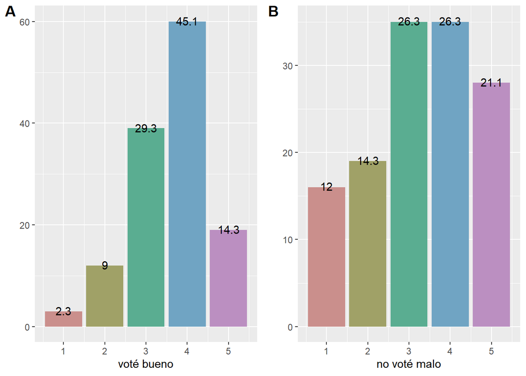

```
##
## $`2`
```

```
##
## attr(,"class")
## [1] "list"      "ggarrange"
```

## INFLUENCIA

Por último, la influencia de las consideraciones morales en las decisiones electorales.

Influencia en el voto en blanco

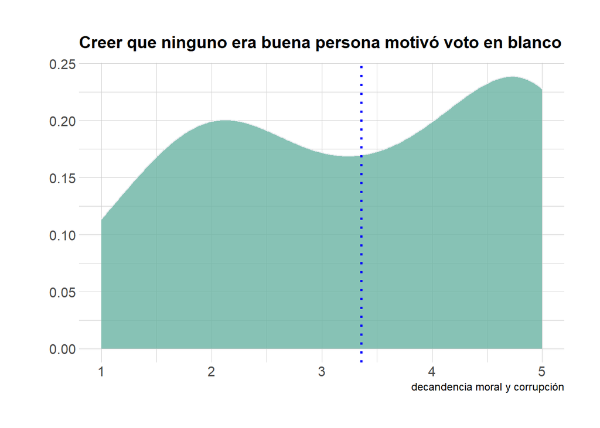

```
## $`1`
```

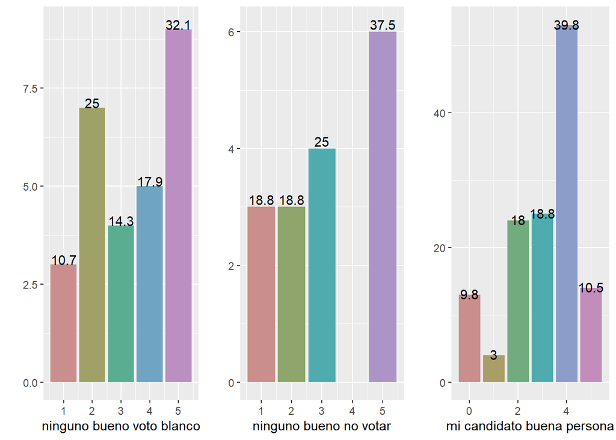

```
##
## $`2`
```

```
##
## attr(,"class")
## [1] "list"      "ggarrange"
```

La anterior con porcentajes

Esta con frecuencia

```
## $`1`
```

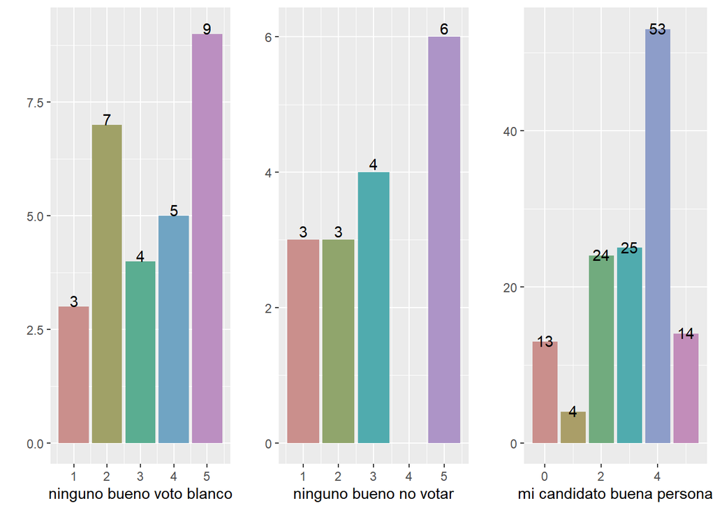

```
##
## $`2`
```

```
##
## attr(,"class")
## [1] "list"      "ggarrange"
```

```
##                no influyó influyó
## voto en blanco         10      14
## no votó                 6       6
## votó                   17      67
```

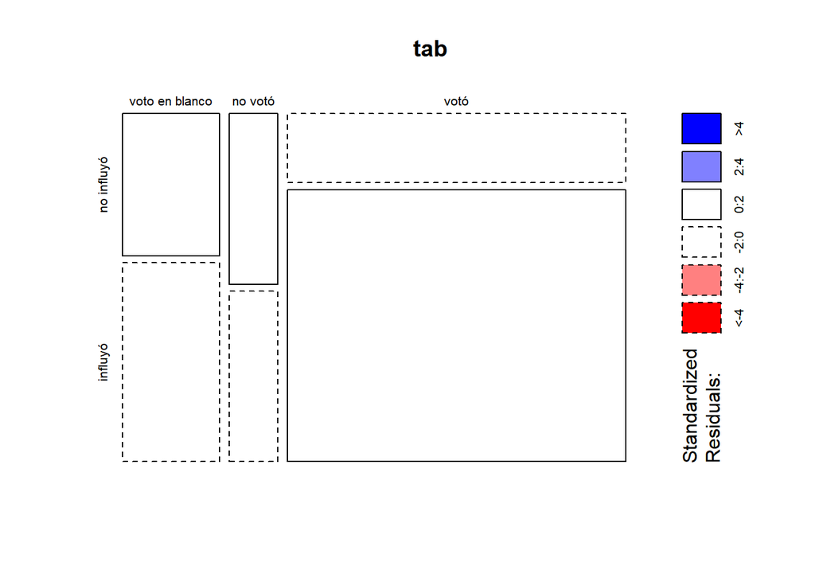

Un test de proporciones

```
##
##  3-sample test for equality of proportions without continuity
##  correction
##
## data:  tab1
## X-squared = 7.6847, df = 2, p-value = 0.02144
## alternative hypothesis: two.sided
## sample estimates:
##    prop 1    prop 2    prop 3
## 0.4166667 0.5000000 0.2023810
```

en cada grupo

Grupo de voto en blanco

```
##
##  1-sample proportions test with continuity correction
##
## data:  tab1, null probability 0.5
## X-squared = 0.375, df = 1, p-value = 0.5403
## alternative hypothesis: true p is not equal to 0.5
## 95 percent confidence interval:
##  0.2279876 0.6305942
## sample estimates:
##         p
## 0.4166667
```

Grupo de voto en blanco no hay diferencia (las consideraciones morales no influyen sobre la decisión de votar en blanco)

Grupo no votó

```
##
##  1-sample proportions test without continuity correction
##
## data:  tab2, null probability 0.5
## X-squared = 0, df = 1, p-value = 1
## alternative hypothesis: true p is not equal to 0.5
## 95 percent confidence interval:
##  0.2537816 0.7462184
## sample estimates:
##   p
## 0.5
```

No hay diferencia (las consideraciones morales no influyen sobre la decisión de no votar)

grupo que votó

```
##
##  1-sample proportions test with continuity correction
##
## data:  tab3, null probability 0.5
## X-squared = 28.583, df = 1, p-value = 0.00000008975
## alternative hypothesis: true p is not equal to 0.5
## 95 percent confidence interval:
##  0.1255672 0.3069685
## sample estimates:
##        p
## 0.202381
```

Sí hay diferencia (las consideraciones morales influyen sobre la decisión de votar por algún candidato)

# CONCLUSIONES GENERALES

Según estos datos y análisis preliminares:

- Hay un clima de moralización de la política en Colombia, pues se cumplen tres condiciones esenciales:
  - Las personas creen que hay decadencia moral en el paísf
  - Las personas creen que esa decadencia moral [individual] está relacionada con problemas [colectivos] del país (corrupción, economía, violencia)
  - Las consideraciones morales parecen influir en las decisiones electorales, especialmente entre las personas que votan por un candidato

NOTA FINAL:

- El problema que planteo aquí podría interprertarse como un problema estrictamente **lógico**: las personas tienden a utilizar un grupo de normas en un dominio en donde no se deberían utilizar, ya que esas normas por definición solo deberían utilizarse en otro dominio.
- Pero, una primera cosa es que ese problema lógico tiene consecuencias prácticas en sí mismas problemáticas: un problema práctico fundamental de usar normas morales para tomar decisiones en el dominio de los problemas colectivos está en la dinámica de las normas. Los problemas colectivos deberían ser enfrentados por normas colectivas no solo por un asunto categorial, sino por un asunto de dinámica: las normas colectivas son normas susceptibles de cambio en las dinámicas colectivas, por eso también son adecuadas para solucionar problemas colectivos, porque el grupo en tanto grupo tiene poder agencial sobre ellas. El problema de aplicar normas morales para solucionar problemas colectivos es que no están (o al menos es lógicamente posible que puedan no estar ) sujetas a una dinámica grupal, por ende, la moralización nos presenta un escenario en el que las soluciones a problemas colectivos vienen de estructuras normativas sobre las que el grupo no tiene mecanismos efectivos para alterar o intervenir
- Como segunda cosa, hay algo más profundo aquí sobre lo que no puedo extenderme, pero quiero hacer un bosquejo del argumento que quisiera defender: realmente creo que no estoy introduciendo un argumento en contra de la moral en general, sino de cierta concepción de la moral que aún siguen teniendo muchas personas, sobre todo personas que no se dedican a hacer teoría moral. Para muchas personas, cuando se habla de moral se habla de moral en sentido normativo y no en sentido descriptivo. En sentido normativo, las teoría moral nos debe especificar cuáles son las normas morales que debemos seguir. En sentido descriptivo (y me inspiro en la obra de Moore para decir estas cosas), hacer teoría moral es describir los sistemas morales, ver cuáles son sus principios, ver si son internamente coherentes, ver deónticamente qué consecuencias prácticas se siguen y cuáles no, ver qué es posible, o necesario, o imposible como acción moral según ese sistema etc. Esto me parece muy relevante sobre todo en el contexto de resultados de la psicología cultural del siglo XX que nos han mostrado, si bien ahora nos parece obvio pero tal vez no siempre fue así, que hay una pluralidad muy grande de sistemas morales: diferentes culturales, en diferentes tiempos, o en diferentes regiones del planeta, han formado diferentes sistemas de normas morales, muchas veces contradictorios entre sí. Dado que existen diferentes rivales de sistemas morales, y no tenemos una manera no-arbitraria de escoger uno sobre el otro, tal vez lo mejor que podemos hacer como teóricos de la moral es hacer moral descriptiva (o narrativa si se quiere), pero abandonar la esperanza de mostrar que un cierto sistema moral es superior a otro, en términos morales. Podemos mostrar que un sistema moral es superior a otro en términos lógicos, semánticos, pragmáticos, pero no en términos morales absolutos, pues no tenemos un criterio ulterior, de orden superior, que nos permita hacerlo. Tal vez si no tuviéramos el problema de la pluralidad de sistemas morales, y tuviéramos un solo sistema moral (e.g. los diez mandamientos), entonces la moral podría ayudar a la política y tal vez lo que se necesitaría es precisamente MÁS MORAL, RECUPERAR LOS PRINCIPIOS MORALES (?), ELEGIR FUNCIONARIOS MORALES, ETC, y demás estrategias que proponen los moralistas. Pero dado que eso no existe, la estrategia de moralización no nos lleva a un buen camino.
- El otro asunto que es tangencial aquí, pero de igual importancia es el asunto de los esquemas de motivación de la acción humana. Aún si uno encontrara que, en un sentido normativo hay un solo sistema moral, es decir que así haya muchos sistemas articulables podemos argumentar que hay uno que es superior a todos los demás sistemas posibles, el problema es que las normas morales no son nuestra única fuerza motivacional. Aún si cogiéramos a todos los políticos y les enseñáramos un sistema de normas morales y aún si fuéramos exitosos en lograr que ellos interiorizaran tales normas morales, eso no sería suficiente para asegurar que esas normas morales vayan a ser sus guías de conducta en todos los escenarios posibles que se les presenten en su ejercicio como políticos.

[AÚN SI NO SE HABLA DE ESTOS DOS ÚLTIMOS PUNTOS, DAR UNA CONCLUSIÓN DE ESTE ESTILO] Pero, dado que en este mundo estamos, y no contamos con esas condicions ideales, necesitamos intentar evitar MORALIZAR LA POLÍTICA.

[NO SÉ SI HABLAR DE ESTO O ESPERAR LAS PREGUNTAS]

- ¿Cómo se logra esto? La solución es Kant (“Respuesta a la pregunta qué es la ilustración”) - necesitamos enseñar a la gente a que separe el uso privado y el uso público de la razón.